# about_algorithm

## About the algorithm

The predictive algorithm implemented in this app was inspired in the Katz Backoff model with a small difference.

While the Katz backoff model only considers the lower a lower level ngram if the higher level ngram is not present. In this model, when calculating the probability of a word, the probability of all ngram levels is calculated, these probabilities are then adjusted according to their ngram level and the maximum value is selected.

As I am not that good with words, here goes an example. Given an trigram Katz backoff model, the probability of a word given its last 2 words would be calculated as follows:

In this model, the probability of a word given its last 2 words is calculated as follows:

This changes very little in the results as the alpha factor, which for some reason I called lambda in the package I created, unless close to or bigger than one, will prevent the probability of a lesser level to out weight the higher values.

It still happens in extreme cases though. This is what I think have brought up my accuracy from about 25% (which is close to what most of the other students have from what I’ve seen) to about 35%.

Besides the backoff, we also had some to cut some ngrams to allow the model to fit in this app. Only ngrams that appeared more than 2 times in the training data are considered in the model. This cutoff value is defined as k.

Finally, the number of predictions the model returns can also be selected. I arbitrarily selected 6 as the number of predictions. Of course, the more predictions I add the more accurate my model is, but at some point this starts getting quite cumbersome. Here is the accuracy values for different numbers of predictions.

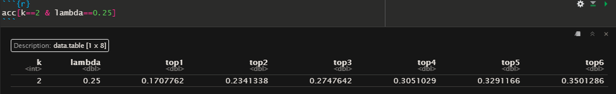

## How it was trained

This values were selected after a DOE experiment involving training several models and testing their accuracies.

## About backoff model

You can learn more about backoff model through the links bellow: - [Smoothing and Backoff, material from the Cornel University](http://www.cs.cornell.edu/courses/cs4740/2014sp/lectures/smoothing+backoff.pdf) - [Katz’s back-off model](https://en.wikipedia.org/wiki/Katz%27s_back-off_model)